# Random effects, and mixed models

DSCI 632: Statistics for Data Science

Peter Ralph

# Random effects

## An example: sleep

From [Belenky et al](https://doi.org/10.1046/j.1365-2869.2003.00337.x), *Patterns of performance degradation and restoration during sleep restriction and subsequent recovery: a sleep dose-response study* (and included in the `lme4` package).

> The average reaction time per day (in milliseconds) for subjects in a sleep deprivation study. These data are from the study described in Belenky et al. (2003), for the most sleep-deprived group (3 hours time-in-bed) and for the first 10 days of the study, up to the recovery period.

```r
library(lme4)
head(sleepstudy)
```

```
##   Reaction Days Subject
## 1 249.5600    0     308
## 2 258.7047    1     308
## 3 250.8006    2     308
## 4 321.4398    3     308
## 5 356.8519    4     308
## 6 414.6901    5     308
```

## How much data do we have?

```r
sleepstudy |> summarize(n=n(), Reaction=mean(Reaction), .by=Subject)
```

```
##    Subject  n Reaction
## 1      308 10 342.1338
## 2      309 10 215.2330
## 3      310 10 231.0013
## 4      330 10 303.2214
## 5      331 10 309.4361
## 6      332 10 307.3021
## 7      333 10 316.1583
## 8      334 10 295.3021
## 9      335 10 250.0700
## 10     337 10 375.7210
## 11     349 10 275.8345
## 12     350 10 313.6027
## 13     351 10 290.0978
## 14     352 10 337.4215
## 15     369 10 306.0346
## 16     370 10 291.7018
## 17     371 10 294.9840
## 18     372 10 317.8861
```

## Do subjects differ?

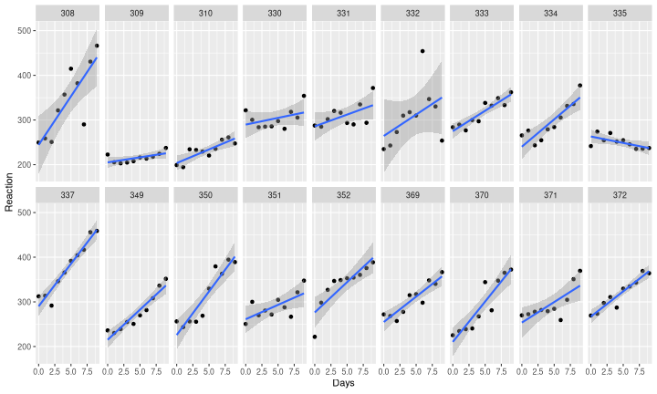

```r
sleepstudy |> ggplot(aes(x=Days, y=Reaction)) +
    geom_point() + geom_smooth(method="lm", formula=y~x) +
    facet_wrap(~ Subject, nrow=2)
```

## First pass: lm()

```r
lm1 <- lm(Reaction ~ Days, data=sleepstudy)
summary(lm1)
```

```
##
## Call:
## lm(formula = Reaction ~ Days, data = sleepstudy)
##
## Residuals:
##      Min       1Q   Median       3Q      Max
## -110.848  -27.483    1.546   26.142  139.953
##
## Coefficients:
##             Estimate Std. Error t value Pr(>|t|)
## (Intercept)  251.405      6.610  38.033  < 2e-16 ***
## Days          10.467      1.238   8.454 9.89e-15 ***
## ---
## Signif. codes:  0 '***' 0.001 '**' 0.01 '*' 0.05 '.' 0.1 ' ' 1
##
## Residual standard error: 47.71 on 178 degrees of freedom
## Multiple R-squared:  0.2865, Adjusted R-squared:  0.2825
## F-statistic: 71.46 on 1 and 178 DF,  p-value: 9.894e-15
```

## How’d that work?

```
Reaction ~ Days
```

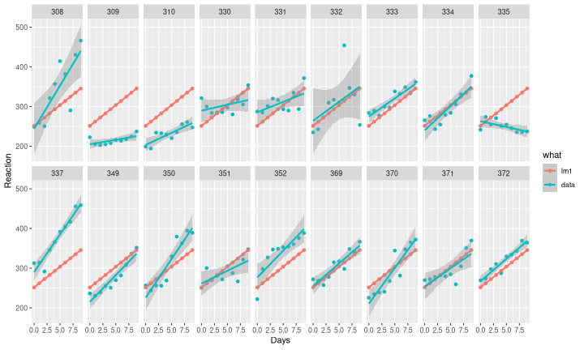

```r
sleep <- sleepstudy |> mutate( lm1 = predict(lm1, newdata=sleepstudy) )
sleep |> pivot_longer(cols=c(Reaction, lm1), values_to="Reaction", names_to="what") |>
    mutate(what=fct_recode(what, data="Reaction")) |>
    ggplot(aes(x=Days, y=Reaction, color=what)) +
    geom_point() + geom_smooth(method="lm", formula=y~x) +
    facet_wrap(~ Subject, nrow=2)
```

*Critique:*

That single line more or less summarizes how much reaction time goes up per night.

After all, it’s what we’d get if we ignored Subject.

But, this is wrong!

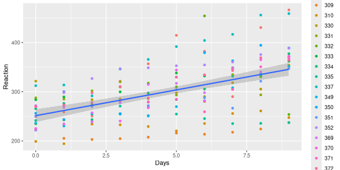

[figure not shown]

xkcd:2533

[xkcd:2533](https://xkcd.com/2533/)

```r
sleep |> ggplot(aes(x=Days, y=Reaction)) +
    geom_point(aes(color=Subject)) + geom_smooth(method="lm", formula=y~x)
```

## A reminder: “the” linear model

```
lm(Reaction ~ Days)
```

fits the model ($R_i$ and $D_i$ are the $i^\text{th}$ Reaction and Days entries)
$$\begin{aligned}
R_i &= b_0 + b_{\text{Days}} \times D_i + \epsilon_i \\
\epsilon_i &\sim \text{Normal}(\text{mean}=0, \text{sd}=\sigma)
,
\end{aligned}$$
where the $\epsilon_i$ are *independent*.

This means that we’ll be *wrong*: overconfident about the estimate.

## Separate lines per subject?

```r
lm2 <- lm(Reaction ~ Days * Subject, data=sleepstudy)
summary(lm2)
```

```
##
## Call:
## lm(formula = Reaction ~ Days * Subject, data = sleepstudy)
##
## Residuals:
##      Min       1Q   Median       3Q      Max
## -106.397  -10.692   -0.177   11.417  132.510
##
## Coefficients:
##                 Estimate Std. Error t value Pr(>|t|)
## (Intercept)      244.193     15.042  16.234  < 2e-16 ***
## Days              21.765      2.818   7.725 1.74e-12 ***
## Subject309       -39.138     21.272  -1.840 0.067848 .
## Subject310       -40.708     21.272  -1.914 0.057643 .
## Subject330        45.492     21.272   2.139 0.034156 *
## Subject331        41.546     21.272   1.953 0.052749 .
## Subject332        20.059     21.272   0.943 0.347277
## Subject333        30.826     21.272   1.449 0.149471
## Subject334        -4.030     21.272  -0.189 0.850016
## Subject335        18.842     21.272   0.886 0.377224
## Subject337        45.911     21.272   2.158 0.032563 *
## Subject349       -29.081     21.272  -1.367 0.173728
## Subject350       -18.358     21.272  -0.863 0.389568
## Subject351        16.954     21.272   0.797 0.426751
## Subject352        32.179     21.272   1.513 0.132535
## Subject369        10.775     21.272   0.507 0.613243
## Subject370       -33.744     21.272  -1.586 0.114870
## Subject371         9.443     21.272   0.444 0.657759
## Subject372        22.852     21.272   1.074 0.284497
## Days:Subject309  -19.503      3.985  -4.895 2.61e-06 ***
## Days:Subject310  -15.650      3.985  -3.928 0.000133 ***
## Days:Subject330  -18.757      3.985  -4.707 5.84e-06 ***
## Days:Subject331  -16.499      3.985  -4.141 5.88e-05 ***
## Days:Subject332  -12.198      3.985  -3.061 0.002630 **
## Days:Subject333  -12.623      3.985  -3.168 0.001876 **
## Days:Subject334   -9.512      3.985  -2.387 0.018282 *
## Days:Subject335  -24.646      3.985  -6.185 6.07e-09 ***
## Days:Subject337   -2.739      3.985  -0.687 0.492986
## Days:Subject349   -8.271      3.985  -2.076 0.039704 *
## Days:Subject350   -2.261      3.985  -0.567 0.571360
## Days:Subject351  -15.331      3.985  -3.848 0.000179 ***
## Days:Subject352   -8.198      3.985  -2.057 0.041448 *
## Days:Subject369  -10.417      3.985  -2.614 0.009895 **
## Days:Subject370   -3.709      3.985  -0.931 0.353560
## Days:Subject371  -12.576      3.985  -3.156 0.001947 **
## Days:Subject372  -10.467      3.985  -2.627 0.009554 **
## ---
## Signif. codes:  0 '***' 0.001 '**' 0.01 '*' 0.05 '.' 0.1 ' ' 1
##
## Residual standard error: 25.59 on 144 degrees of freedom
## Multiple R-squared:  0.8339, Adjusted R-squared:  0.7936
## F-statistic: 20.66 on 35 and 144 DF,  p-value: < 2.2e-16
```

```
Reaction ~ Days * Subject
```

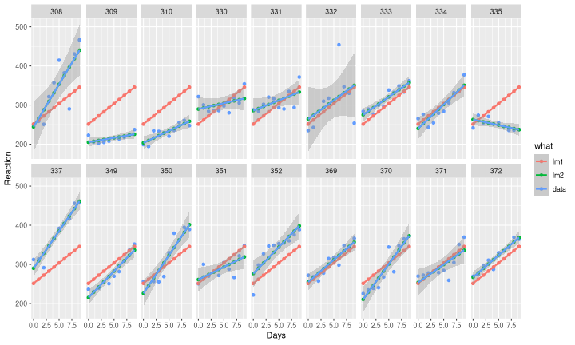

```r
sleep <- sleep |> mutate( lm2 = predict(lm2, newdata=sleepstudy) )
sleep |> pivot_longer(cols=c(Reaction, lm2, lm1), values_to="Reaction", names_to="what") |>
    mutate(what=fct_recode(what, data="Reaction")) |>
    ggplot(aes(x=Days, y=Reaction, color=what)) +
    geom_point() + geom_smooth(method="lm", formula=y~x) +
    facet_wrap(~ Subject, nrow=2)
```

## What’d we do there?

```
lm(Reaction ~ Days * Subject)
```

fits the model ($R_i$, $D_i$ and $S_i$ are the $i^\text{th}$ Reaction, Days, and Subject entries)
$$\begin{aligned}
R_{i} &= b_{S_i,0} + b_{S_i,\text{Days}} \times D_i + \epsilon_i
\\
\epsilon_i &\sim \text{Normal}(\text{mean}=0, \text{sd}=\sigma)
.
\end{aligned}$$
The $\epsilon_i$ are still independent, but there’s a different slope and intercept for each subject.

**But** we wanted to know the *overall* effect!

# Random effects

Here’s one approach:
$$\begin{aligned}
R_{i} &= b_0 + b_\text{Days} \times D_i + b_{S_i,0} +
b_{S_i,\text{Days}} \times D_i + \epsilon_i \\
\epsilon_i &\sim \text{Normal}(\text{mean}=0,
\text{sd}=\sigma) \\
b_{S_i,0} &\sim \text{Normal}(\text{mean}=0, \text{sd}=\eta) \\
b_{S_i,\text{Days}} &\sim \text{Normal}(\text{mean}=0,
\text{sd}=\eta) \\
\end{aligned}$$
We’re allowing *subject-specific deviations* from a common slope and intercept.

## `lme4::lmer`

*This* has *random intercepts and slopes* by subject:

```r
fm1 <- lmer(Reaction ~ Days + (Days | Subject), data=sleepstudy)
summary(fm1)
```

```
## Linear mixed model fit by REML ['lmerMod']
## Formula: Reaction ~ Days + (Days | Subject)
##    Data: sleepstudy
##
## REML criterion at convergence: 1743.6
##
## Scaled residuals:
##     Min      1Q  Median      3Q     Max
## -3.9536 -0.4634  0.0231  0.4634  5.1793
##
## Random effects:
##  Groups   Name        Variance Std.Dev. Corr
##  Subject  (Intercept) 612.10   24.741
##           Days         35.07    5.922   0.07
##  Residual             654.94   25.592
## Number of obs: 180, groups:  Subject, 18
##
## Fixed effects:
##             Estimate Std. Error t value
## (Intercept)  251.405      6.825  36.838
## Days          10.467      1.546   6.771
##
## Correlation of Fixed Effects:
##      (Intr)
## Days -0.138
```

Here are the estimated random effects themselves:

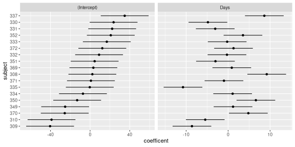

```r
rf1 <- ranef(fm1) |> as.data.frame()
rf1 |> ggplot(aes(y=grp, x=condval)) +
    geom_point() + facet_wrap(~term, scales="free_x") +
    geom_errorbar(aes(xmin=condval -2*condsd,
                      xmax=condval +2*condsd), width=0) +
    labs(x="coefficent", y="subject")
```

And, the per-subject results:

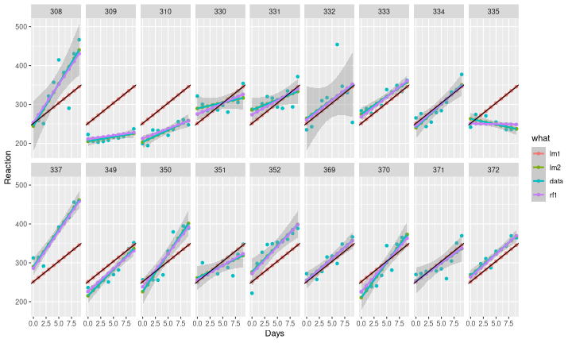

```r
sleep <- sleep |> mutate(
    rf1 = predict(fm1, newdata=sleepstudy)
)
sleep |> pivot_longer(cols=c(Reaction, lm2, lm1, rf1), values_to="Reaction", names_to="what") |>
    mutate(what=fct_recode(what, data="Reaction")) |>
    ggplot(aes(x=Days, y=Reaction, color=what)) +
    geom_point() + geom_smooth(method="lm", formula=y~x) +
    geom_abline(slope=fixef(fm1)["Days"], intercept=fixef(fm1)["(Intercept)"]) +
    facet_wrap(~ Subject, nrow=2)
```

# Another example: urchins

## An example: urchins eat algae

From Logan:

> To investigate density-dependent grazing effects of sea urchin Andrew and Underwood (1993) on filamentous algae measured the percentage of filamentous algae within five quadrats randomly positioned within each of four random patches of reef that were in turn nested within four sea urchin density treatments (no urchins, 33% of natural density, 66% natural density and 100% natural density). The sea urchin density treatment was considered a fixed factor and patch within density treatment as well as the individual quadrats were treated as random factors.

## An example: urchins eat algae

```r
andrew_data <- read.table('../datasets/Logan_data/andrew.tsv', header=T, sep='\t')
head(andrew_data)
```

```
##   TREAT PATCH QUAD ALGAE
## 1    0%     1    1    46
## 2    0%     1    2    44
## 3    0%     1    3    41
## 4    0%     1    4    29
## 5    0%     1    5    11
## 6    0%     2    1    65
```

There are four variables: `TREAT`, `PATCH`, `QUAD` and `ALGAE`

Main effect factor: `TREAT`

Both `QUAD` and `PATCH` are factors:

```r
andrew_data$QUAD <- factor(andrew_data$QUAD)
andrew_data$PATCH <- factor(andrew_data$PATCH)
andrew_data$TREAT <- factor(andrew_data$TREAT, levels=c("0%", "33%", "66%", "100%"))
```

## Experimental design

```r
with(andrew_data, table(PATCH, QUAD, TREAT))
```

```
## , , TREAT = 0%
##
##      QUAD
## PATCH 1 2 3 4 5
##    1  1 1 1 1 1
##    2  1 1 1 1 1
##    3  1 1 1 1 1
##    4  1 1 1 1 1
##    5  0 0 0 0 0
##    6  0 0 0 0 0
##    7  0 0 0 0 0
##    8  0 0 0 0 0
##    9  0 0 0 0 0
##    10 0 0 0 0 0
##    11 0 0 0 0 0
```

[output cut: 68 more lines]

## Response distribution

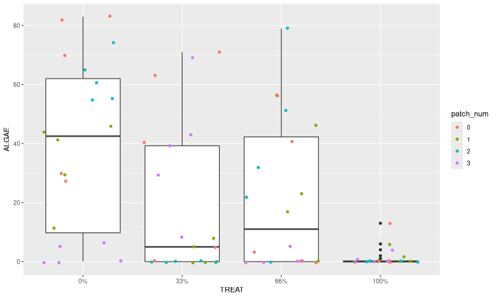

```r
andrew_data |> mutate(patch_num=factor(as.numeric(PATCH)%%4)) |>
    ggplot(aes(x=TREAT, y=ALGAE)) + geom_boxplot() +
    geom_jitter(aes(color=patch_num))
```

Why is this wrong?

```r
summary(lm(ALGAE ~ TREAT, data=andrew_data))
```

```
##
## Call:
## lm(formula = ALGAE ~ TREAT, data = andrew_data)
##
## Residuals:
##    Min     1Q Median     3Q    Max
## -39.20 -19.00  -1.30  12.72  57.45
##
## Coefficients:
##             Estimate Std. Error t value Pr(>|t|)
## (Intercept)   39.200      5.152   7.608 6.17e-11 ***
## TREAT33%     -20.200      7.287  -2.772   0.0070 **
## TREAT66%     -17.650      7.287  -2.422   0.0178 *
## TREAT100%    -37.900      7.287  -5.201 1.62e-06 ***
## ---
## Signif. codes:  0 '***' 0.001 '**' 0.01 '*' 0.05 '.' 0.1 ' ' 1
##
## Residual standard error: 23.04 on 76 degrees of freedom
## Multiple R-squared:  0.2634, Adjusted R-squared:  0.2343
## F-statistic: 9.059 on 3 and 76 DF,  p-value: 3.362e-05
```

What we really want:
$$\text{(algae)} = \text{(mean for treatment)} + \text{(mean offset for
patch)} + \text{("noise")} .$$

We *could* do:

```
ALGAE ~ TREAT + PATCH
```

… but do we care about all those patch means?

```r
summary(lm(ALGAE ~ TREAT + PATCH, data=andrew_data))
```

```
##
## Call:
## lm(formula = ALGAE ~ TREAT + PATCH, data = andrew_data)
##
## Residuals:
##    Min     1Q Median     3Q    Max
## -36.80  -2.60  -0.50   4.25  42.20
##
## Coefficients: (3 not defined because of singularities)
##             Estimate Std. Error t value Pr(>|t|)
## (Intercept)   34.200      7.728   4.426 3.82e-05 ***
## TREAT33%       1.600     10.929   0.146  0.88406
## TREAT66%     -14.200     10.929  -1.299  0.19850
## TREAT100%    -31.600     10.929  -2.891  0.00523 **
## PATCH2        27.800     10.929   2.544  0.01339 *
## PATCH3       -32.000     10.929  -2.928  0.00472 **
## PATCH4        24.200     10.929   2.214  0.03038 *
## PATCH5       -33.200     10.929  -3.038  0.00345 **
## PATCH6       -35.800     10.929  -3.276  0.00170 **
## PATCH7         1.800     10.929   0.165  0.86970
## PATCH8            NA         NA      NA       NA
## PATCH9         8.400     10.929   0.769  0.44495
## PATCH10       16.800     10.929   1.537  0.12917
## PATCH11      -19.000     10.929  -1.739  0.08693 .
## PATCH12           NA         NA      NA       NA
## PATCH13       -1.000     10.929  -0.092  0.92738
## PATCH14       -2.600     10.929  -0.238  0.81272
## PATCH15       -1.600     10.929  -0.146  0.88406
## PATCH16           NA         NA      NA       NA
## ---
## Signif. codes:  0 '***' 0.001 '**' 0.01 '*' 0.05 '.' 0.1 ' ' 1
##
## Residual standard error: 17.28 on 64 degrees of freedom
## Multiple R-squared:  0.6512, Adjusted R-squared:  0.5694
## F-statistic: 7.964 on 15 and 64 DF,  p-value: 1.05e-09
```

## Random effects

Small modification:
$$\text{(algae)} = \text{(mean for treatment)} + \text{(random offset for
patch)} + \text{("noise")} .$$

We add a *random intercept*:

```
ALGAE ~ TREAT + (1|PATCH)
```

```r
library(lme4)
alglm <- lmer(ALGAE ~ TREAT + (1|PATCH), data=andrew_data)
summary(alglm)
```

```
## Linear mixed model fit by REML ['lmerMod']
## Formula: ALGAE ~ TREAT + (1 | PATCH)
##    Data: andrew_data
##
## REML criterion at convergence: 682.2
##
## Scaled residuals:
##     Min      1Q  Median      3Q     Max
## -1.9808 -0.3106 -0.1093  0.2831  2.5910
##
## Random effects:
##  Groups   Name        Variance Std.Dev.
##  PATCH    (Intercept) 294.3    17.16
##  Residual             298.6    17.28
## Number of obs: 80, groups:  PATCH, 16
##
## Fixed effects:
##             Estimate Std. Error t value
## (Intercept)   39.200      9.408   4.167
## TREAT33%     -20.200     13.305  -1.518
## TREAT66%     -17.650     13.305  -1.327
## TREAT100%    -37.900     13.305  -2.849
##
## Correlation of Fixed Effects:
##           (Intr) TREAT3 TREAT6
## TREAT33%  -0.707
## TREAT66%  -0.707  0.500
## TREAT100% -0.707  0.500  0.500
```

```r
anova(
      lmer(ALGAE ~ TREAT + (1|PATCH), data=andrew_data),
      lm(ALGAE ~ TREAT, data=andrew_data))
```

```
## refitting model(s) with ML (instead of REML)
```

```
## Data: andrew_data
## Models:
## lm(ALGAE ~ TREAT, data = andrew_data): ALGAE ~ TREAT
## lmer(ALGAE ~ TREAT + (1 | PATCH), data = andrew_data): ALGAE ~ TREAT + (1 | PATCH)
##                                                       npar    AIC    BIC  logLik -2*log(L)  Chisq Df Pr(>Chisq)
## lm(ALGAE ~ TREAT, data = andrew_data)                    5 734.90 746.81 -362.45    724.90
## lmer(ALGAE ~ TREAT + (1 | PATCH), data = andrew_data)    6 718.83 733.12 -353.42    706.83 18.069  1   2.13e-05 ***
## ---
## Signif. codes:  0 '***' 0.001 '**' 0.01 '*' 0.05 '.' 0.1 ' ' 1
```

```r
anova(
      lmer(ALGAE ~ TREAT + (1|PATCH), data=andrew_data),
      lmer(ALGAE ~ (1|PATCH), data=andrew_data))
```

```
## refitting model(s) with ML (instead of REML)
```

```
## Data: andrew_data
## Models:
## lmer(ALGAE ~ (1 | PATCH), data = andrew_data): ALGAE ~ (1 | PATCH)
## lmer(ALGAE ~ TREAT + (1 | PATCH), data = andrew_data): ALGAE ~ TREAT + (1 | PATCH)
##                                                       npar    AIC    BIC  logLik -2*log(L)  Chisq Df Pr(>Chisq)
## lmer(ALGAE ~ (1 | PATCH), data = andrew_data)            3 721.12 728.27 -357.56    715.12
## lmer(ALGAE ~ TREAT + (1 | PATCH), data = andrew_data)    6 718.83 733.12 -353.42    706.83 8.2938  3    0.04031 *
## ---
## Signif. codes:  0 '***' 0.001 '**' 0.01 '*' 0.05 '.' 0.1 ' ' 1
```

## What *are* the random effects?

```r
ranef(alglm)
```

```
## $PATCH
##    (Intercept)
## 1   -4.1565746
## 2   18.9539802
## 3  -30.7586522
## 4   15.9612465
## 5  -13.6335647
## 6  -15.7949835
## 7   15.4624576
## 8   13.9660907
## 9    5.6945072
## 10  12.6775526
## 11 -17.0835217
## 12  -1.2885381
## 13   0.2493945
## 14  -1.0807094
## 15  -0.2493945
## 16   1.0807094
##
## with conditional variances for "PATCH"
```

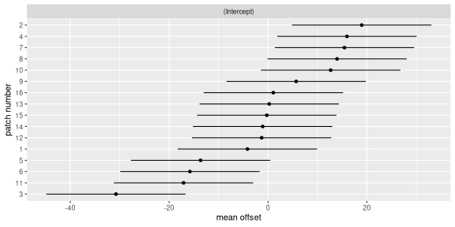

```r
ranef(alglm) |> as.data.frame() |> ggplot(aes(y=grp, x=condval)) +
    geom_point() + facet_wrap(~term, scales="free_x") +
    geom_errorbar(aes(xmin=condval -2*condsd,
                      xmax=condval +2*condsd), width=0) +
    labs(x="mean offset", y="patch number")
```

# Notes on mixed models

## The math is a lot harder.

For a simple linear model fit by `lm( )` (with *fixed effects*), the *log-likelihood function* is just the sum of the squared residuals.

But with a *mixed model*, the likelihood *averages* over the values of the random effects, which makes everything more difficult.

## You sometimes have to worry about *convergence*.

Since the math is harder, mixed-model-fitting functions like `lmer( )` have to use various sorts of *numerical optimization* methods to find the best-fitting parameters.

Sometimes, these may fail.

Notably, many use the [`REML`](https://en.wikipedia.org/wiki/Restricted_maximum_likelihood) approximation:

```
Usage:

     lmer(formula, data = NULL, REML = TRUE, control = lmerControl(),
          start = NULL, verbose = 0L, subset, weights, na.action,
          offset, contrasts = NULL, devFunOnly = FALSE, ...)
```

## Hypothesis testing?

With fixed effects, for a factor `f`, the comparison

```
anova( lm(y ~ f - 1), lm(y ~ 1) )
```

uses the model that
$$y_i = \beta_{f_i} +
\epsilon_i$$
to test against the null hypothesis that
$$H_0 : \beta_1 = \beta_2 = \cdots = \beta_m = 0.$$

With *random* effects,

```
anova( lm(y ~ (1|f) - 1), lm(y ~ 1) )
```

uses the model that
$$\begin{aligned}
y_i &= \beta_{f_i} + \epsilon_i \\
\beta_a &\sim \Normal(0, \eta)
\end{aligned}$$
to test against the null hypothesis that
$$H_0 : \eta = 0.$$

# Back to the pumpkins

## Your turn

1. Adjust the simulations so that there is an effect of `plot`, drawn randomly from Normal(0, 1).
2. Fit a model including a *random effect* for `plot`.
3. How big is the “plot” effect? Is it estimated correctly?
4. Assess significance by using `anova( )` to compare to a nested model.

## Simulate data

(Here’s our previous code:)

```r
pumpkins <- expand.grid(
          fertilizer=c("low", "medium", "high"),
          water=c("no water", "water"),
          plot=1:4,
          plant=1:5,
          weight=NA)

params <- list(
    mu = 5, # all units are kg
    alpha = c(low=0, medium=2, high=4),
    beta = c("no water"=0, water=1),
    sigma = 1
)
params$gamma <- rep(0, 6)
names(params$gamma) <- outer(c("low", "medium", "high"), c("no water", "water"), paste, sep=",")
params$gamma["high,water"] <-  5

pumpkins$condition <- paste(pumpkins$fertilizer, pumpkins$water, sep=",")
pumpkins$mean_weight <-
    params$mu +
    params$alpha[pumpkins$fertilizer] +
    params$beta[pumpkins$water] +
    params$gamma[pumpkins$condition]

set.seed(123)
pumpkins$weight <- rnorm(nrow(pumpkins), mean=pumpkins$mean_weight, sd=params$sigma)
```